# ODE integration and sensitivity analysis

## Basic ODE integration

We can solve the cauchy problem using `scipy odeint` function.

This function needs:

- a function that describes the derivative of the system
- the starting state of the system
- the time points over which to integrate
- parameters describing the differential equation, that will be routed to the derivative function

```python
from scipy.integrate import odeint

import numpy as np
import seaborn as sns
import pylab as plt
import pandas as pd
import scipy.stats as st
```

Let's try to solve the following differential equation with parameter $k=0.4$ and initial condition $y_{0}=6$:

$$ \frac{dy(t)}{dt}=-ky(y) $$

```python
def model(y, t):
    k = 0.4
    dydt = -k*y
    return dydt
```

```python
# initial condition
y0 = 6

# time points
t = np.linspace(0, 30, 100+1)

# solve ODE
y = odeint(model, y0, t)
```

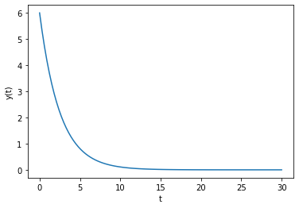

```python
plt.plot(t, y)
plt.xlabel('t')
plt.ylabel('y(t)')
plt.show()
```

An optional input of `odeint` function is **args** that allows additional information to be passed into the **model** function.

The args input is a tuple sequence of values.

```python
def model(y, t, k):
    dydt = -k*y
    return dydt
```

```python
k = 0.1
y1 = odeint(model, y0, t, args=(k,))

k = 0.3
y2 = odeint(model, y0, t, args=(k,))

k = 0.6
y3 = odeint(model, y0, t, args=(k,))
```

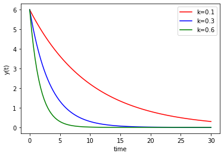

```python
plt.plot(t, y1, 'r', label='k=0.1')
plt.plot(t, y2, 'b', label='k=0.3')
plt.plot(t, y3, 'g', label='k=0.6')
plt.xlabel('time')
plt.ylabel('y(t)')
plt.legend(loc='best')
plt.show()
```

## Logistic growth

$$ \frac{dy(t)}{dt}=ry(t)\left(1-\frac{y(t)}{k}\right) $$

where $y(t)$ is the size of the population at time $t$, $r$ is the growth rate and $k$ is the carrying capacity, that is the number of people, other living organisms, or crops that a region can support without environmental degradation.

```python
def logistic(y, t, r, k):
    dydt = r*y*(1 - y/k)
    return dydt
```

```python
# time steps
t = np.linspace(0, 1, 100+1)

# initial condition
y0 = 0.1

# parameters
r = 10
k = 1

# solve ODE
y = odeint(logistic, y0, t, args=(r, k))
```

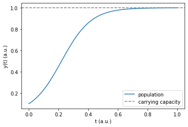

```python
plt.plot(t, y, label='population')
plt.xlabel('t (a.u.)')
plt.ylabel('y(t) (a.u.)')
plt.axhline(k, label='carrying capacity', color='gray', linestyle='--')
plt.legend(loc='best')
plt.show()
```

# Sensitivity analysis of ODE

It is convenient to transform the result of the integration in a pandas dataframe.

This allows us to use it for better visualization through seaborn.

```python
def create_df(result, columns, **other_info):
    df = pd.DataFrame(result, columns=columns)
    for key, value in other_info.items():
        df[key] = value
    return df
```

```python
create_df(y, ['population'], r=r, k=k, time=t).head()
```

|  | population | r | k | time |
| --- | --- | --- | --- | --- |
| 0 | 0.100000 | 10 | 1 | 0.00 |
| 1 | 0.109367 | 10 | 1 | 0.01 |
| 2 | 0.119495 | 10 | 1 | 0.02 |
| 3 | 0.130423 | 10 | 1 | 0.03 |
| 4 | 0.142189 | 10 | 1 | 0.04 |

```python
# randomly generate 50 normally distributed values of r around the value r=10
rates = np.random.normal(r, 0.5, 50)

results = []
idx = 0
for ri in rates:
    ys = odeint(logistic, y0, t, args=(ri, k))
    ys_df = create_df(ys, ['population'], r=ri, k=k, time=t, simulation_run=idx)
    results.append(ys_df)
    idx = idx + 1
results = pd.concat(results, ignore_index=True)
```

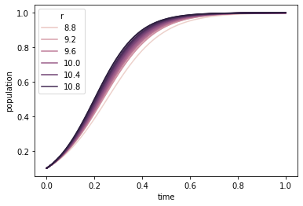

```python
sns.lineplot(x="time", y="population", data=results, hue='r',
             estimator=None, units='simulation_run')
```

```python
# randomly generate 50 normally distributed values of k
capacities = np.random.normal(k, 0.05, 50)

results = []
idx = 0
for ci in capacities:
    ys = odeint(logistic, y0, t, args=(r, ci))
    ys_df = create_df(ys, ['population'], r=r, k=ci, time=t, simulation_run=idx)
    results.append(ys_df)
    idx = idx + 1
results = pd.concat(results, ignore_index=True)
```

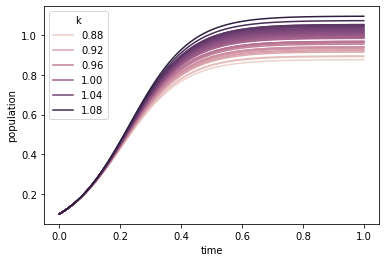

```python
sns.lineplot(x="time", y="population", data=results, hue='k',
             estimator=None, units='simulation_run')
```

## SIR model

The SIR model describes the evolution of a disease in a population.

$$ \left\{ \begin{array}{l} \frac{dS(t)}{dt} = -\left(\frac{\beta}{N}\right)S(t)I(t) &\\ \frac{dI(t)}{dt} = \left(\frac{\beta}{N}\right)S(t)I(t) - (r + d)I(t) &\\ \frac{dR(t)}{dt} = rI(t) &\\ \frac{dD(t)}{dt} = dI(t) \end{array} \right. $$

where:

- **S** = susceptible individuals, healthy subjects that can be infected.
- **I** = infected individuals, able to infect susceptible subjects if they meet.
- **R** = resistant or recovered individuals, subjects that have survived the illness and can not be infected again.
- **D** = deceased individuals, subjects that did not survive the infection.

We will represent all the populations using normalized concentrations.

```python
def sir(state, t, a, b, c):
    S, I, R, D = state
    dSdt = - a*S*I
    dIdt = + a*S*I - b*I - c*I
    dRdt = + b*I
    dDdt = + c*I
    return dSdt, dIdt, dRdt, dDdt
```

```python
# time steps
t = np.linspace(0, 5, 100+1)

# initial condition
state0 = (0.999, 0.001, 0.0, 0.0)

# parameters
a, b, c = 10, 1, 0.3

# solve ODE
res = odeint(sir, state0, t, args=(a, b, c))
```

```python
res.shape
```

```
(101, 4)
```

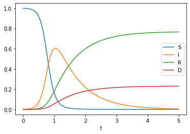

```python
plt.plot(t, res[:,0], label='S')
plt.plot(t, res[:,1], label='I')
plt.plot(t, res[:,2], label='R')
plt.plot(t, res[:,3], label='D')
plt.xlabel('t')
plt.legend(loc='best')
plt.show()
```

What happens if we change the value of one of the parameters?

```python
# randomly generate 50 normally distributed values of b around the value b=1
b_range = np.random.normal(b, 0.1, 50)

results = []
cols = ['S', 'I', 'R', 'D']
idx = 0
for bi in b_range:
    res_i = odeint(sir, state0, t, args=(a, bi, c))
    res_i_df = create_df(res_i, cols, a=a, b=bi, c=c, time=t, simulation_run=idx, type='varying b')
    results.append(res_i_df)
    idx = idx + 1
results = pd.concat(results, ignore_index=True)
```

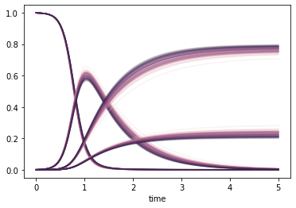

```python
args = dict(data=results, estimator=None, units='simulation_run', alpha=0.25, hue='b', legend=False)
sns.lineplot(x="time", y='S', **args).set(ylabel='')
sns.lineplot(x="time", y='I', **args).set(ylabel='')
sns.lineplot(x="time", y='R', **args).set(ylabel='')
sns.lineplot(x="time", y='D', **args).set(ylabel='')
plt.show()
```

We can observe what difference it makes if we let each parameter fluctuate one at the time, while fixing the others.

```python
# parameters
a, b, c = 10, 1, 0.3

results = []
cols = ['S', 'I', 'R', 'D']

# randomly generate 50 normally distributed values of a around the value a=10
a_range = np.random.normal(a, a*0.1, 50)
idx = 0
for ai in a_range:
    res_i = odeint(sir, state0, t, args=(ai, b, c))
    res_i_df = create_df(res_i, cols, a=ai, b=b, c=c, time=t, simulation_run=idx, type='varying a')
    results.append(res_i_df)
    idx = idx + 1

# randomly generate 50 normally distributed values of b around the value b=1
b_range = np.random.normal(b, b*0.1, 50)
idx = 0
for bi in b_range:
    res_i = odeint(sir, state0, t, args=(a, bi, c))
    res_i_df = create_df(res_i, cols, a=a, b=bi, c=c, time=t, simulation_run=idx, type='varying b')
    results.append(res_i_df)
    idx = idx + 1

# randomly generate 50 normally distributed values of b around the value c=0.3
c_range = np.random.normal(c, c*0.1, 50)
idx = 0
for ci in c_range:
    res_i = odeint(sir, state0, t, args=(a, b, ci))
    res_i_df = create_df(res_i, cols, a=a, b=b, c=ci, time=t, simulation_run=idx, type='varying c')
    results.append(res_i_df)
    idx = idx + 1
results = pd.concat(results, ignore_index=True)
```

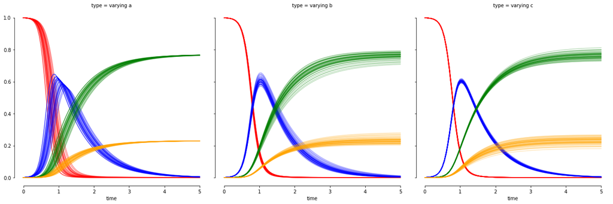

```python
fg = sns.FacetGrid(data=results, col='type', sharex=False, height=6, legend_out=False)
fg.map_dataframe(sns.lineplot, x="time", y='S', estimator=None, units='simulation_run', alpha=0.25, color='r')
fg.map_dataframe(sns.lineplot, x="time", y='I', estimator=None, units='simulation_run', alpha=0.25, color='b')
fg.map_dataframe(sns.lineplot, x="time", y='R', estimator=None, units='simulation_run', alpha=0.25, color='g')
fg.map_dataframe(sns.lineplot, x="time", y='D', estimator=None, units='simulation_run', alpha=0.25, color='orange')
fg.set(ylabel=None)
sns.despine(fg.fig, trim=True)
```

To have a better understanding, we could also use a subset of the phase space, to see how different variables change over time.

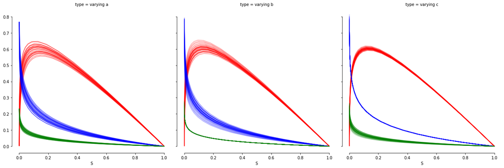

```python
fg = sns.FacetGrid(data=results, col='type', height=6)
fg.map_dataframe(sns.lineplot, x="S", y='I', estimator=None, units='simulation_run', alpha=0.25, color='r')
fg.map_dataframe(sns.lineplot, x="S", y='R', estimator=None, units='simulation_run', alpha=0.25, color='b')
fg.map_dataframe(sns.lineplot, x="S", y='D', estimator=None, units='simulation_run', alpha=0.25, color='g')
fg.set(ylabel=None)
sns.despine(fg.fig, trim=True)
```

To have a better understanding of the be behavior of the system, we could also fix a parameter and let the others change randomly.

By observing the resulting variance point by point we can infer the relevance of each parameter.

This is the basic approach for the global sensitivity analysis as used by Saltelli at al., and is the implementation basis of the SALib we saw last lesson.

## Sampling with noise

A different approach to sensitity analysis is to try to generate random samples that replicate a possible measurement, fit the ODE parameters and observe how they change and covariate.

```python
scale = 100

t = np.linspace(0, 5, 50+1)
state0 = (0.999, 0.001, 0.0, 0.0)
a, b, c = 10, 1, 0.3

res = odeint(sir, state0, t, args=(a, b, c))
S_hat, I_hat, R_hat, D_hat = res.T
```

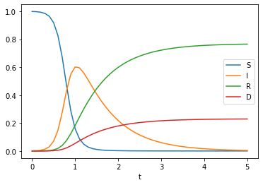

```python
plt.plot(t, S_hat, label='S')
plt.plot(t, I_hat, label='I')
plt.plot(t, R_hat, label='R')
plt.plot(t, D_hat, label='D')
plt.xlabel('t')
plt.legend(loc='best')
plt.show()
```

The easiest way to do this is to use gaussian noise.

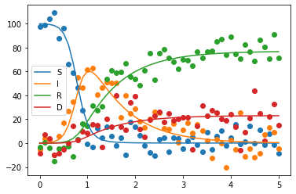

```python
S_hat_normal, I_hat_normal, R_hat_normal, D_hat_normal = st.norm.rvs(loc=res*scale, scale=0.1*scale).T

plt.plot(t, S_hat*scale, label='S')
plt.plot(t, I_hat*scale, label='I')
plt.plot(t, R_hat*scale, label='R')
plt.plot(t, D_hat*scale, label='D')

plt.scatter(t, S_hat_normal)
plt.scatter(t, I_hat_normal)
plt.scatter(t, R_hat_normal)
plt.scatter(t, D_hat_normal)

plt.legend(loc='best')
plt.show()
```

This clearly has problems, such as the population appearing negative!

It would be better to use a different sampling, such as the Poisson distribution.

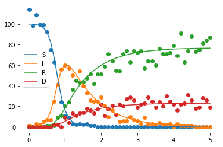

```python
S_hat_poisson, I_hat_poisson, R_hat_poisson, D_hat_poisson = st.poisson.rvs(res*scale).T

plt.plot(t, S_hat*scale, label='S')
plt.plot(t, I_hat*scale, label='I')
plt.plot(t, R_hat*scale, label='R')
plt.plot(t, D_hat*scale, label='D')

plt.scatter(t, S_hat_poisson)
plt.scatter(t, I_hat_poisson)
plt.scatter(t, R_hat_poisson)
plt.scatter(t, D_hat_poisson)

plt.legend(loc='best')
plt.show()
```

## Fitting

Let's see the fitting procedure itself.

In a similar way to odeint, we will use the `curve_fit` function that will give us an estimate of the parameters and their correlations.

To do this, it takes a function that, given the x values and a set of parameters, it gives the prediction.

```python
from scipy.optimize import curve_fit
# ydata = f(xdata, *params) + eps
```

Let's study it with a linear regression first.

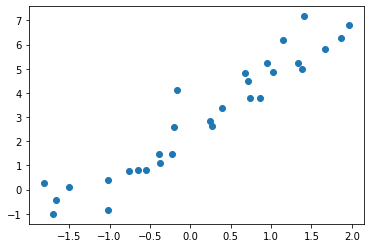

```python
x = plt.randn(30)
y = 2*x + 3 + plt.randn(30)*0.8
plt.scatter(x, y)
plt.show()
```

```python
def linear_fit(xdata, m, q):
    return m*xdata + q

p_avg, p_cov = curve_fit(linear_fit, x, y, p0=[1, 0])
```

```python
p_avg
```

```
array([2.1034913 , 2.67607236])
```

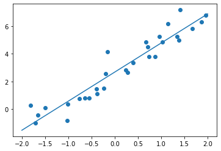

```python
x_values = np.linspace(-2, 2, 51)
y_hat = linear_fit(x_values, *p_avg)
plt.scatter(x, y)
plt.plot(x_values, y_hat)
plt.show()
```

## How to visualize uncertainty?

- normal sampling
- 95% quantiles representation

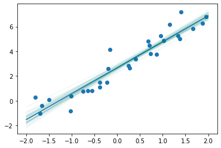

```python
p_seq = st.multivariate_normal.rvs(mean=p_avg, cov=p_cov, size=50)
x_base = np.linspace(-2, 2, 51)
y_hat = linear_fit(x_base, *p_avg)
plt.scatter(x, y)
plt.plot(x_base, y_hat)

for params in p_seq:
    y_hat = linear_fit(x_base, *params)
    plt.plot(x_base, y_hat, color='teal', alpha=0.05)
```

```python
from scipy.stats.mstats import mquantiles
```

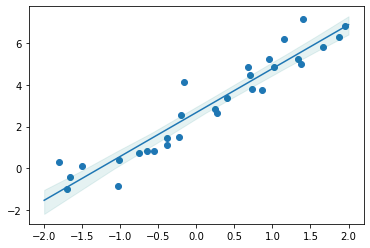

```python
p_seq = st.multivariate_normal.rvs(mean=p_avg, cov=p_cov, size=50)
x_base = np.linspace(-2, 2, 101)
y_hat = linear_fit(x_base, *p_avg)

plt.scatter(x, y)
plt.plot(x_base, y_hat)
y_hat = [linear_fit(x_base, *params) for params in p_seq]
y_hat = np.stack(y_hat)

p_low, p_top = mquantiles(y_hat, prob=[0.025, 0.975], axis=0)
plt.fill_between(x_base, p_low, p_top, alpha=0.1, color='teal')
plt.show()
```

Let's go back to the logistic growth model and try to apply this method to perform sensitivity analysis.

```python
def logistic(y, t, r, k):
    dydt = r*y*(1 - y/k)
    return dydt
```

```python
# time steps
t = np.linspace(0, 1, 50+1)

# initial condition
y0 = 0.1

# parameters
r = 10
k = 1

# solve ODE
y = odeint(logistic, y0, t, args=(r, k))
```

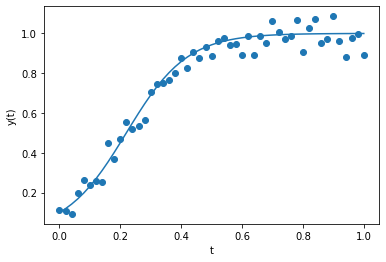

```python
y_hat_normal = st.norm.rvs(loc=y, scale=0.05)

plt.plot(t, y)
plt.scatter(t, y_hat_normal)
plt.xlabel('t')
plt.ylabel('y(t)')
plt.show()
```

```python
def logistic_fit(xdata, r, k):
    y0 = 0.1
    res = odeint(logistic, y0, xdata, args=(r, k))
    return res[:,0]

p_avg, p_cov = curve_fit(logistic_fit, t, y_hat_normal[:,0], p0=[1, 0.1])
```

```python
p_avg
```

```
array([9.87788241, 0.98401019])
```

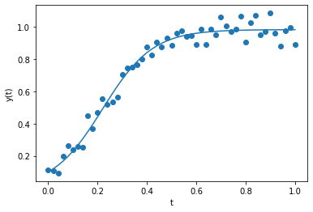

```python
y_fit = logistic_fit(t, *p_avg)

plt.scatter(t, y_hat_normal)
plt.plot(t, y_fit)
plt.xlabel('t')
plt.ylabel('y(t)')
plt.show()
```

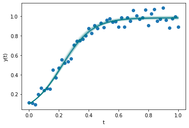

```python
p_seq = st.multivariate_normal.rvs(mean=p_avg, cov=p_cov, size=50)


plt.scatter(t, y_hat_normal)
plt.plot(t, y_fit)
plt.xlabel('t')
plt.ylabel('y(t)')
for params in p_seq:
    y_hat_ = logistic_fit(t, *params)
    plt.plot(t, y_hat_, color='teal', alpha=0.05)
plt.show()
```

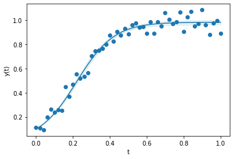

```python
p_seq = st.multivariate_normal.rvs(mean=p_avg, cov=p_cov, size=50)

plt.scatter(t, y_hat_normal)
plt.plot(t, y_fit)
plt.xlabel('t')
plt.ylabel('y(t)')
y_hat_2 = [logistic_fit(t, *params) for params in p_seq]
y_hat_2 = np.stack(y_hat_2)

p_low, p_top = mquantiles(y_hat_2, prob=[0.025, 0.975], axis=0)
plt.fill_between(t, p_low, p_top, alpha=0.1, color='teal')
plt.show()
```

## Exercise

Consider the simple ODE shown as first example today:

$$ \frac{dy(t)}{dt}=-ky(y) $$

with parameter $k=0.4$ and initial condition $y_{0}=6$.

Perform sensitivity analysis according to the two methods seen today.